# Inference vignette

# Inference

Even though FlexiDeconv utilises reference during inference, it is only used as prior information, meaning cell type gene expression profile will be actively estimated using both Spatial Transcriptomics data and the reference. Typically, we invite users to perform interpretation on these estimated cell types (e.g., identifying marker genes), however, we do provide a way of interpreting these cell types as described in this Vignette.

```r
library(FlexiDeconv)
```

For the Spatial Transcriptomics data (mouseHypothalamus), we borrowed from (Moffitt et al. 2018), which has a total of 30 mice, with both female and male. We selected the second mouse because it has the largest number of slices available. To simulate low data signal scenario, we subsampled only two slices, with $slice = -0.09$ and $slice = 0.21$. Furthermore, we filtered 135 genes following STdeconvolve’s simulation setup (Miller et al. 2022), in order to be consistent.

We provide the deconvolution result by FlexiDeconv after supplying imperfect reference obtained from (Zeng n.d.). Note that to make the situation more realistic, we reduced the read count of the spatial data by a factor of 30, so that it is closer to a real Visium dataset considering the relatively low genes.

```r
data(imperfectReferenceResult)
data(mouseHypothalamus)
```

Upon loading the data, we first plot the correlation between the provided gene expression profile against the estimated gene expression profile. This should guide us to infer the identity of the estimated cell types.

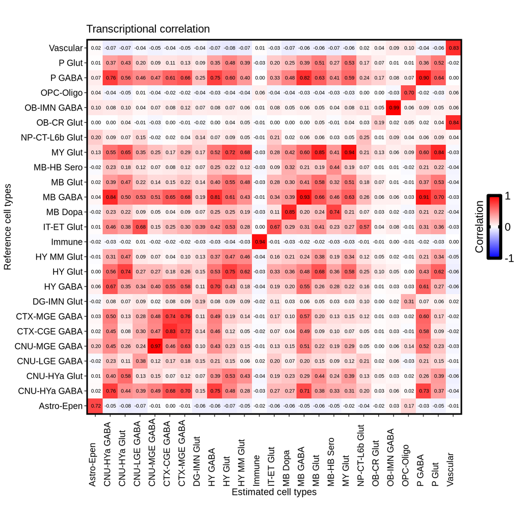

```r
corMatrixPlot(as.matrix(imperfectReferenceResult$reference),
              as.matrix(imperfectReferenceResult$tau),
              rowlab = "Reference cell types",
              collab = "Estimated cell types")
```

The first step of the identity assignment process assigns cell types to their original provided cell type, if the correlation between provided and estimated gene expression profile exceeds certain threshold. This threshold should be determined by the user.

From different experiments, we found that this threshold value vary for different gene set size. The intuitition behind that is including more genes that are lowly expressed increases the correlation (as those differentiating marker genes now only take a small subset of the entire gene set). Hence, we would suggest this threshold value should be selected based on the correlation matrix plot from above.

```r
originalIdentityAssigned = identityAssignment(imperfectReferenceResult$tau,
                                              imperfectReferenceResult$reference,
                                              imperfectReferenceResult$gamma,
                                              threshold = 0.7)
```

```
## Astro-Epen is assigned to itself
```

```
## CNU-HYa GABA is assigned to itself
```

```
## CNU-MGE GABA is assigned to itself
```

```
## CTX-CGE GABA is assigned to itself
```

```
## CTX-MGE GABA is assigned to itself
```

```
## HY GABA is assigned to itself
```

```
## HY Glut is assigned to itself
```

```
## Immune is assigned to itself
```

```
## MB Dopa is assigned to itself
```

```
## MB GABA is assigned to itself
```

```
## MY Glut is assigned to itself
```

```
## OB-IMN GABA is assigned to itself
```

```
## P GABA is assigned to itself
```

```
## Vascular is assigned to itself
```

The second step of the identity assignment process assigns unlabelled cell types (i.e., unlabelled in step 1) to other cell types, if its correlation with other provided cell type is greater than an user defined threshold.

It is possible that FlexiDeconv “gives up” on a (or some) cell type(s) by ignoring the prior at all, and use this cell type to estimate other ones.

```r
otherIdentityAssigned = identityAssignmentOther(imperfectReferenceResult$tau,
                                                imperfectReferenceResult$reference,
                                                imperfectReferenceResult$gamma,
                                                originalIdentityAssigned$unknownIdentity,
                                                originalIdentityAssigned$assignedDeconvRes,
                                                originalIdentityAssigned$assignedGeneExp,
                                                threshold = 0.7)
```

```
## OB-CR Glut is assigned to Vascular
```

The final third step of the identity assignment process clusters the rest unknown cell types. The procedure is as follows: 1. For the unknown cell types, order from least abundant to most abundant. 2. From the least abundant cell type, find the cell type (within the unknown ones) with maximum correlation, if the correlation is greater than an user-defined threshold, then the cell type is merged.

```r
unknownClusteredCT = unknownCluster(imperfectReferenceResult$tau,
                                          imperfectReferenceResult$gamma,
                                          otherIdentityAssigned$unknownIdentity,
                                          otherIdentityAssigned$assignedDeconvRes,
                                          otherIdentityAssigned$assignedGeneExp,
                                          threshold = 0.6)
```

```
## Estimated P Glut is merged with estimated CNU-HYa Glut
```

```
## Estimated MB-HB Sero becomes Unknown 1
```

```
## Estimated CNU-LGE GABA becomes Unknown 2
```

```
## Estimated MB Glut becomes Unknown 3
```

```
## Estimated DG-IMN Glut becomes Unknown 4
```

```
## Estimated NP-CT-L6b Glut becomes Unknown 5
```

```
## Estimated IT-ET Glut becomes Unknown 6
```

```
## Estimated HY MM Glut becomes Unknown 7
```

```
## Estimated CNU-HYa Glut becomes Unknown 8
```

```
## Estimated OPC-Oligo becomes Unknown 9
```

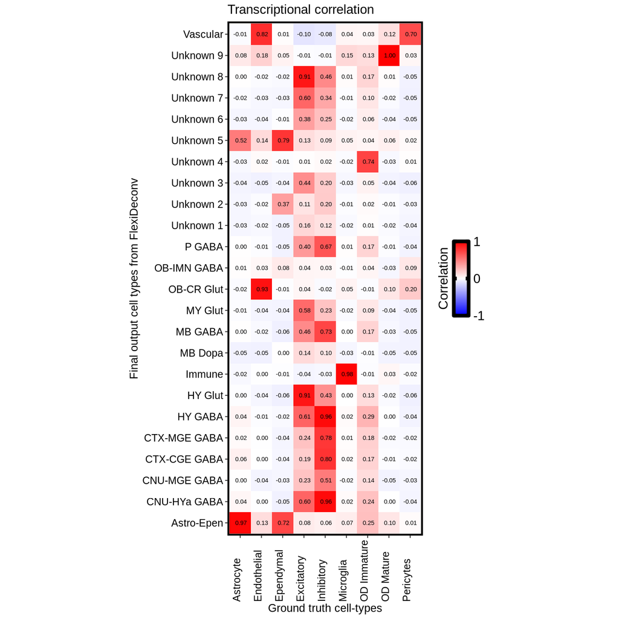

```r
corMatrixPlot(as.matrix(mouseHypothalamus$ground_truth_geneexp),
              as.matrix(unknownClusteredCT$finalGeneExp),
              rowlab = "Final output cell types from FlexiDeconv")
```

Since this is simulation, given the final output after applying interpretations, we map each cell type to the ground truth based on highest correlation and plot our result.

```r
color = c('Astrocyte'='red', 'Endothelial'='orange',
             'Ependymal'='black', 'Excitatory'='blue',
             'Inhibitory'='green', 'Microglia'='purple',
             'OD Immature'='yellow', 'OD Mature'='brown',
             'Pericytes'='cyan')
est_gt_corr = cor(as.matrix(t(mouseHypothalamus$ground_truth_geneexp)),
                  t(as.matrix(unknownClusteredCT$finalGeneExp/rowSums(as.matrix(unknownClusteredCT$finalGeneExp)))),
                  method = "pearson")
new_color = rep("black", ncol(unknownClusteredCT$finalDeconvRes))
names(new_color) = colnames(unknownClusteredCT$finalDeconvRes)
for (ct in names(new_color)) {
  new_color[ct] = color[which.max(est_gt_corr[,ct])]
}

# retrieving the legend object that will be part of the visualization later
legend_grob <- getLegendGrob(new_color)
```

Then we plot the deconvolution result. Since we are using imperfect reference, we do not expect the result to be 100% aligned with the ground truth. But we can see that most of the ground truth cell types are recovered.

```
## Plotting scatterpies for 321 pixels with 23 cell-types...this could take a while if the dataset is large.
```

```
## Plotting scatterpies for 322 pixels with 23 cell-types...this could take a while if the dataset is large.
```

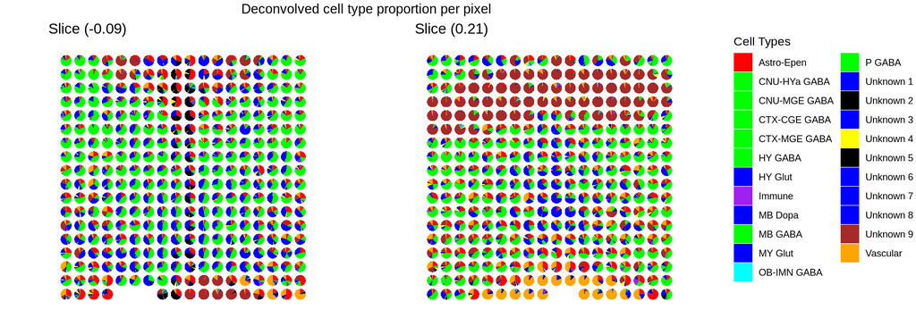

```r
plotDeconvRes(unknownClusteredCT$finalDeconvRes/rowSums(unknownClusteredCT$finalDeconvRes),
              mouseHypothalamus$spatial_meta,
              color = new_color,
              numRow = 1,
              numCol = 2,
              legend_grob = legend_grob,
              title = "Deconvolved cell type proportion per pixel")
```

Miller, B. F., F. Huang, L. Atta, et al. 2022. “Reference-Free Cell Type Deconvolution of Multi-Cellular Pixel-Resolution Spatially Resolved Transcriptomics Data.” *Nature Communications* 13: 2339. https://doi.org/10.1038/s41467-022-30033-z.

Moffitt, Jeffrey R., Dhananjay Bambah-Mukku, Stephen W. Eichhorn, et al. 2018. “Data from: Molecular, Spatial and Functional Single-Cell Profiling of the Hypothalamic Preoptic Region.” Dryad. https://doi.org/10.5061/dryad.8t8s248.

Zeng, Hongkui. n.d. “Cell-Type Specific Molecular Signatures of Aging Revealed in a Brain-Wide Transcriptomic Cell-Type Atlas.” Neuroscience Multi-Omic Archive (NeMO Archive). Accessed December 25, 2025. https://assets.nemoarchive.org/dat-61kfys3.